# 3. Applied Regression I

2023-02-06

> [*Back to content page*](https://flatter11.github.io/r.studio/)

Learning objectives

- Apply poisson and negative binomial regression models to count data
- Identify and apply suitable model to overdispersed data

# 1. Analysis of count data

## Characteristics of count data

- Usually violates the assumptions of linear regression model e.g. Homoscedasticity, Normality
  1. **Non-negative**
  2. Always **positively skewed** (longer tail on RHS)
  3. Variance tends to **increase** with mean, e.g., error in counting 1000 vs 10 ppl; as oppose to things like measuring with ruler – always having error of 1mm
- Examples of count data
  - daily number of ER visits, adverse drugs events, weekly number of influenza hospitalization

## Poisson distribution

- This statistical distribution can be very useful for modelling count data
- The Poisson distribution has **only one parameter, μ** *(as oppose to normal distribution where mean and variance can vary)*
  - The notation Y ~ Poisson(μ) indicates that a variable Y follows a Poisson distribution with parameter μ.
  - Y can take any non-negative integer value, i.e. it could be 0, 1, 2, 3, …, 100, 101…
  - If Y ~ Poisson(μ), the probability of any particular value of Y is given by this probability mass function (pmf):

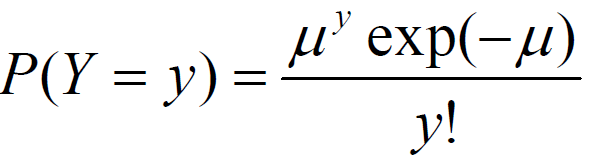

- `dpois(x,lambda/μ)` …distribution `rpois(x, lambda/μ)`…random

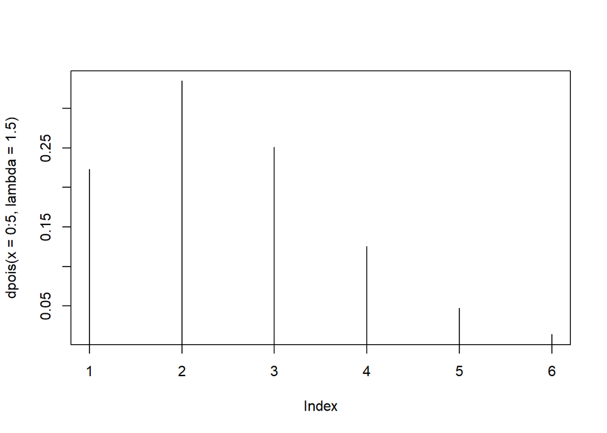

```r
##The probablity of x, given poisson distribution with μ=1.5
plot(dpois(x=0:5, lambda=1.5), type='h')
```

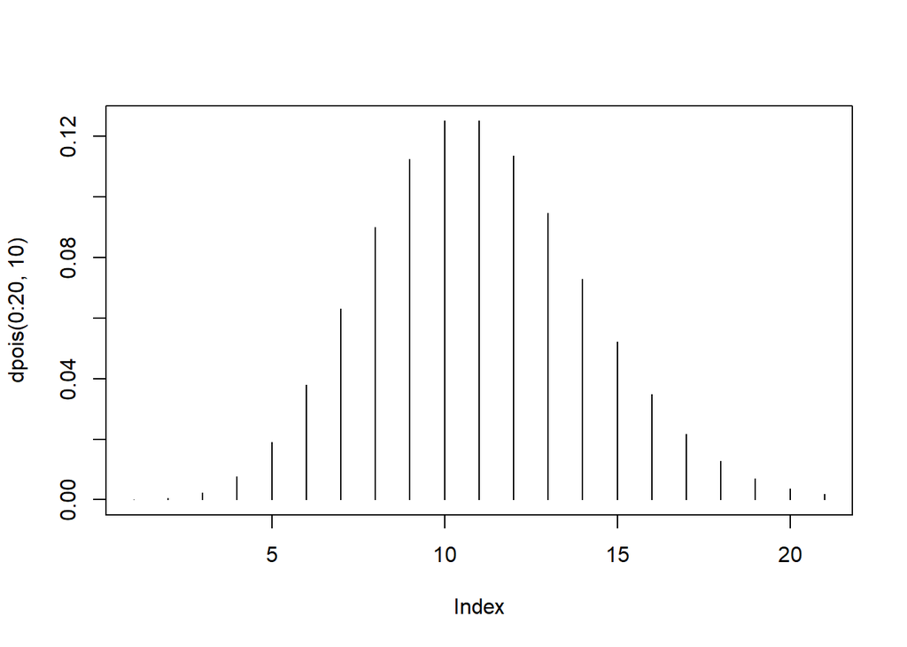

```r
#like normal distribution but there is no negative value
plot(dpois(0:20,10),type="h") #Large enough mean --> approximate/looks
```

```r
##Random number under poisson distribution with u=1.5
rpois(5,1.5)

#Mean and variance are the same
mean(rpois(1000,1.5))
var(rpois(1000,1.5))
```

```
## [1] 1 0 3 1 2
## [1] 1.571
## [1] 1.615607
```

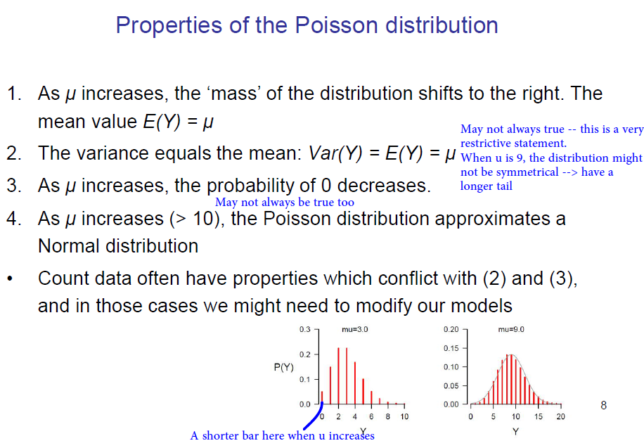

Supplementary info about poisson distribution

### Example dataset – accidents

- In the Prussian army, 1875-94, some unlucky soldiers died by being kicked by a horse (accidentally!)
- The columns are ‘year’, ‘corps’ (army section), and number of deaths
- Can we predict the number of accidental deaths in 1895? Is there any difference over time, or between corps?
  - By plotting deaths~corps or years, we found no major differences between corps or between years -> Propose using the following simple model for the deaths:
  - Each year, and in each corps, deaths occurred randomly with mean μ (per year)

  ```r
  horse <- read.csv("Folder/examplehorse.csv")
  ```

# 2. Generalized linear model

- Classic model which includes linear regression, logistic regression and poisson regression
  - **Generalize it/ make it more flexible**
  - Errors don’t have to follow the Normal distribution, but instead can follow Binomial, Poisson, Gamma distributions…
- Main components of GLM:
  1. Systematic component:
     - **Link function** g which links the outcome variable to the linear predictor
     - g(E(Y)) = α + β1X1 + β2X2 + β3X3 + …
  2. Random component:
     - Specifying variance to mean relation
     - e.g. poisson: σ2 = μ; negative binomial: σ2 = μ + αμ2
- **A link function** maps a nonlinear relationship to a linear one so that a linear model can be fit (and then mapped to the original form)
  - From $E(Y) = β_{1}X_{1}+β_{2}X_{2}+…$
  - to $l(E(Y))= β_{1}X_{1}+β_{2}X_{2}+…$
    - For example, in logistic regression (**binary outcome**), we want to find the **probability of success**: P(Y = 1). This cannot be a linear function of any predictors, but the **log of the odds of success**, log(odds), can.
    - Log(odds) is the link function for logistic regression.
    - Once we fit the model, we can then back-transform the estimated regression coefficients off of a log scale so that we can interpret the conditional effects of each X.

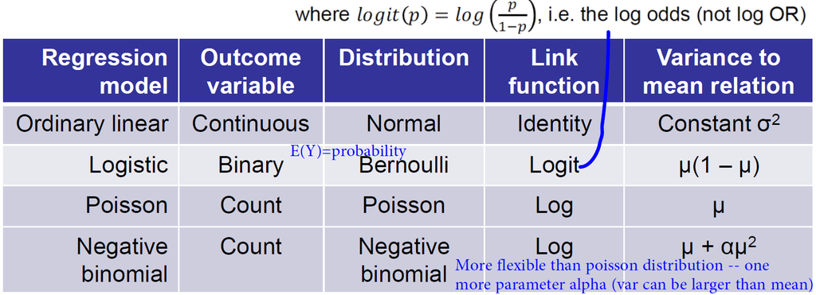

## A. Formula

- `glm(formula, data, subset, family, …)`!!!!!!!!!!!
  - **formula** similar to lm, e.g. y~x+z
  - **data** indicates the data frame to be used
  - **subset** indicates that only some of the data should be used
  - **family** is the distribution of the errors(what type of regression u wanna fit)
    - for Poisson regression: family = poisson
    - for logistic regression: family = binomial

  ```r
  ##y~1 to find out the intercept; intercept is the constant
  ##(expected mean value of Y when X =0)
  pois.horse <- glm(deaths ~ 1, data=horse, family=poisson)
  coef(pois.horse) #log(E(Y)) intercept
  exp(coef(pois.horse)) #E(Y) intercept
  exp(confint(pois.horse)) #E(Y) 95%CI...note 95%CI after exp might not be symmetrical
  mean(horse$deaths) #observed intercept
  ```

  ```
  ## (Intercept)
  ##  -0.4942963
  ## (Intercept)
  ##        0.61
  ##     2.5 %    97.5 %
  ## 0.5080600 0.7247332
  ## [1] 0.61
  ```

### Why use ‘log-link’?

Estimating log(μ) instead of μ has a few useful consequences:

1. We can use Normal distribution theory for the estimated parameters (e.g. to compose confidence intervals)
   - Follow normal distribution after transformation – can construct 95% CI
2. The estimation procedure works better
   - Variance increase with mean (effect is disproportional), after taking log, effect becomes multiplicative
3. We can easily specify the effects of the explanatory variables to be proportional on the event rate (see later)

## (i) Model checking (does glm fit well?)

We can compare the observed event counts to data that we might have expected, under a Poisson(0.61) model

```r
prop.table(table(horse$deaths)) #Observed proportions of number of deaths
dpois(0:5, exp(coef(pois.horse))) #Expected proportions of number of deaths

table(horse$deaths) #Observed frequency of number of deaths
n <- nrow(horse)
n*dpois(0:5, exp(coef(pois.horse))) #Expected frequency of number of deaths
```

```
##
##     0     1     2     3     4
## 0.545 0.325 0.110 0.015 0.005
## [1] 0.5433508688 0.3314440303 0.1010904293 0.0205550540 0.0031346457
## [6] 0.0003824268
##
##   0   1   2   3   4
## 109  65  22   3   1
## [1] 108.67017375  66.28880605  20.21808587   4.11101080   0.62692915
## [6]   0.07648536
```

## (ii) Formal model goodness-of-fit

- Residual deviance/df should not be too much bigger than 1 (better if it is below 1)
- If do not fit well, be aware of this in conlcusion / change a model.

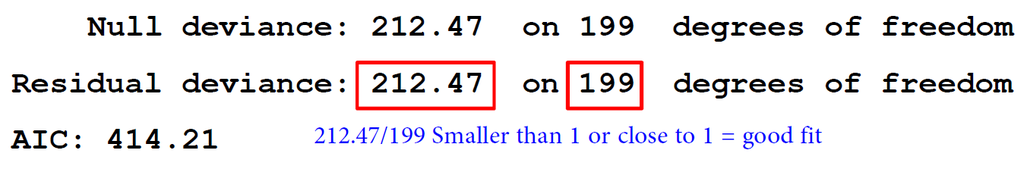

```r
names(pois.horse) #check the names
deviance(pois.horse)/df.residual(pois.horse)
```

## B. Adjusting for independent (explanatory) variables

  ```r
  ##convert corps into factor, we don't want it to be continuous
  class(horse$corps) #check what class it is
  horse$corps <- as.factor(horse$corps)

  ##Result
  pois.corps <- (glm(deaths~corps, data=horse, family=poisson))
  pois.corps
  #Note only corps 14 is statistically significant
  #Goodness to fit is good: deviance/df is close to 1 (= 1.04)
  ```

### Interpretation of result – IRR / relative risk

Let’s think about the predicted mean in army corps 14, compared to the rate in army corps 2. In our model the two predicted means are:

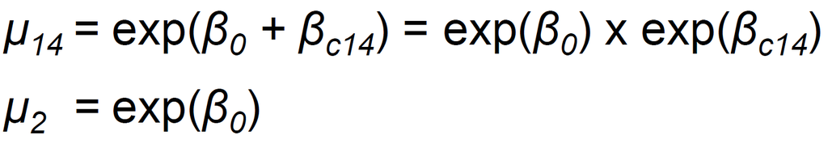

**Multiplicative effect**: The ratio of the means is μ14 / μ2, or simply exp(βc14). We can say that the mean in corps 14 is exp(βc14) times the mean in corps 2.

```r
##Incidence rate ratio/rate ratio
exp(coef(pois.corps))
round(exp(coef(pois.corps)),2) #Round estimate to 2 d.p.
##95%CI
round(exp(cbind(coef(pois.corps), confint(pois.corps))),2)
```

### Conclusions from example

- The overall mean number of deaths per corps per year from horsekicks was 0.61
- A Poisson model fitted the data very well (goodness to fit)
- The corps were fairly similar, although the mean in corps 14 seemed to be a bit higher than the rest (IRR=2.0, 95% CI: 1.0-4.1)

## C. Account for exposures and rates

- Event count will follow a Poisson distribution with mean μ = Aλ
  - Each event happens with some rate λ per unit time;
  - Each group is exposed for a period A (often given in person-years);
  - Independent event (The occurrence of one event doesn’t have any effect on the chance of other events occurring)

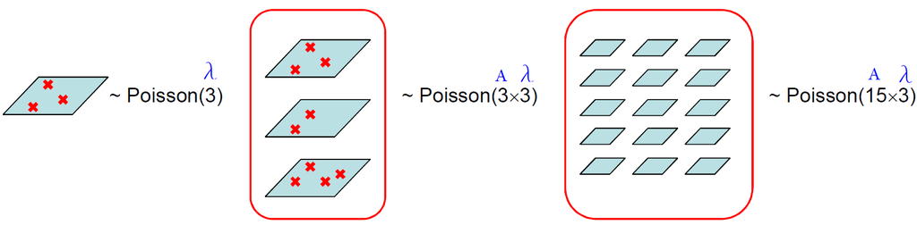

### Example dataset 2 – Lung Cancer Rates

- The file ‘examplelung.csv’ contains data on the number of lung cancer cases (count) and population sizes (pop) by age groups in four Danish cities, in the year 1995
- We are interested in comparing the cancer incidence between cities. However the cities are not all the same size, so we wouldn’t expect the counts to be the same. What can we do?

  ```r
  lung <- read.csv("Folder/examplelung.csv")
  ```

### Poisson regression with offsets(exposure)

- We can model the lung cancer incidence Y<sub>i</sub> (in a particular city and age group of size A<sub>i</sub>) by a Poisson model:
- $Y_{i} \sim\ Poisson(A_{i}λ_{i})$ where λ<sub>i</sub> = exp(β<sub>xi</sub>)

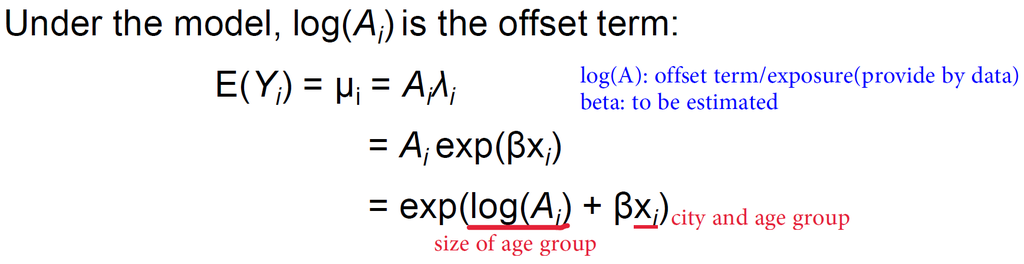

```r
##Note how the offset term is added
pois.lung <- glm(count~offset(log(pop))+city+age.gp,data=lung, family=poisson)
pois.lung
round(exp(cbind(coef(pois.lung), confint(pois.lung))),3)
#Result interpretation:
#City Kolding has 31% lower risk of cx adjusted for age
#Older age group has higher risk of cx
#Goodness to fit = 23/15 = 1.5 -- not well fit

##Side note: can check types of city names
unique(lung$city)
```

## (i) Model checking (prediction)

- `predict(object, newdata=NULL, type=c(“link”, “response”, “terms”), …)`
  - **object** is a fitted GLM model
  - **newdata** (optional, data frame) to predict values for new data
  - **type**: control the scale of the prediction
    - “response” – original scale. Will give the predicted values for the response variable E(Y)
    - “link” – log scale. Will give the predicted values for the link function l(E(Y))
  - **interval**
    - “prediction” – generate lower and upper prediction interval (see tutorial 1)
  - EX: `predict(pois.lung, type='response')` …Use the fitted glm model to predict values

  ```r
  ### Method 2 (not taught in lecture)
  #Predicted incidence vs observed incidence by age group for Fredericia
  ## observed incidences
  with(lung,round(count[city=="Fredericia"]/pop[city=="Fredericia"]*1000,2))
  #With: Evaluate an Expression in a Data Environment
  ## Or
  round(lung$count[lung$city=="Fredericia"]/lung$pop[lung$city=="Fredericia"]*1000,2)

  ## predicted incidences
  new <- data.frame(city="Fredericia",age.gp=lung$age.gp[1:6],pop=lung$pop[1:6])
  round(predict(pois.lung,newdata=new,type='response')/lung$pop[lung$city=="Fredericia"]
        *1000,2)
  ```

### Conclusions from example 2

- We can present the estimated incidence rate ratios of lung cancer between the four cities, and in different age groups
- We can say that incidence increases with age
- We can say that the highest age-adjusted incidence is in Fredericia (city 1) and the lowest age-adjusted incidence is in Kolding (city 3)

## Summary (comparison of A vs B vs C)

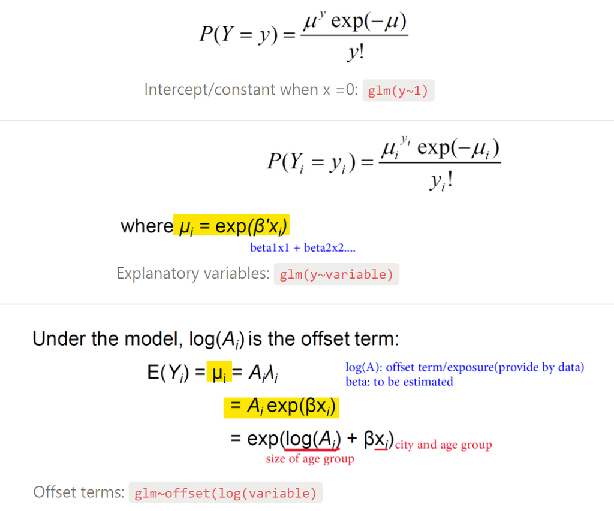

Interpretation:

1. glm(y~1)  
   exp(coef(glm)) = mean/variance for poisson distribution
   - Note for glm.nb:
     - Mean is the same (μ<sub>i</sub>)
     - But variance = μ<sub>i</sub> + αμ<sub>i</sub><sup>2</sup> (θ = 1 / α)
2. glm(y~variable)  
   exp(coef(glm)) = multiplicative effect of the variable *due to log-link function*
   - `round(exp(cbind(coef(glm), confint(glm))),3)`
   - `deviance(glm)/df.residual(glm)`
   - `AIC(glm1, glm2)`

Note:

- Originally `glm(formula, data, subset, family, …)`
- When we suspect overdispersion, we use `glm.nb(formula, data, subset, …)`
  - Where **exp(ε<sub>i</sub>)** follows a gamma distribution with mean 1 and variance α, and **Yi** follows a negative binomial distribution

# 3. Overdispersion

- In many situations, we find that count data have a particular property which makes the Poisson model unsuitable for use – the variance of our count data is appreciably larger than the mean, this is known as **‘overdispersion’**.
- We can generalise the Poisson regression model to include a **‘random effect’ ε<sub>i</sub>** in the rate λ
  - Introduce some uncertainty into the model –> larger variance
  - We can think of ε<sub>i</sub> as representing the effects of one or more unobserved explanatory variables

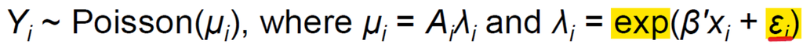

- In the special case where we allow **exp(ε<sub>i</sub>)** to follow a gamma distribution with **mean 1** and **variance α**, then **Yi** follows a **negative binomial distribution** [wiki](https://en.wikipedia.org/wiki/Negative_binomial_distribution) with
  - **Mean = μ<sub>i</sub>**
  - **Variance = μ<sub>i</sub> + αμ<sub>i</sub><sup>2</sup>**
    - Variance always greater than mean (coz αμ<sub>i</sub><sup>2</sup> is a non-negative part)
    - Larger α, larger variance

  ```r
  ## rpois(10000,5): generate 10000 number following poisson distribution with mean = 5
  mean(rpois(10000,5))
  var(rpois(10000,5))

  ## Introduce a random effect following gamma mean=1, variance=2
  # mean = kϑ; variance = kϑ^2
  # shape k; rate β = 1/ϑ
  mean(rpois(10000, 5*rgamma(10000,1/2,1/2)))
  var(rpois(10000, 5*rgamma(10000,1/2,1/2))) #larger variance, suitable to describe count
  #data with overdispersion
  ```

When we try to fit regression model for count data, we start with negative binomial model instead of poisson model and check whether alpha close to 0.

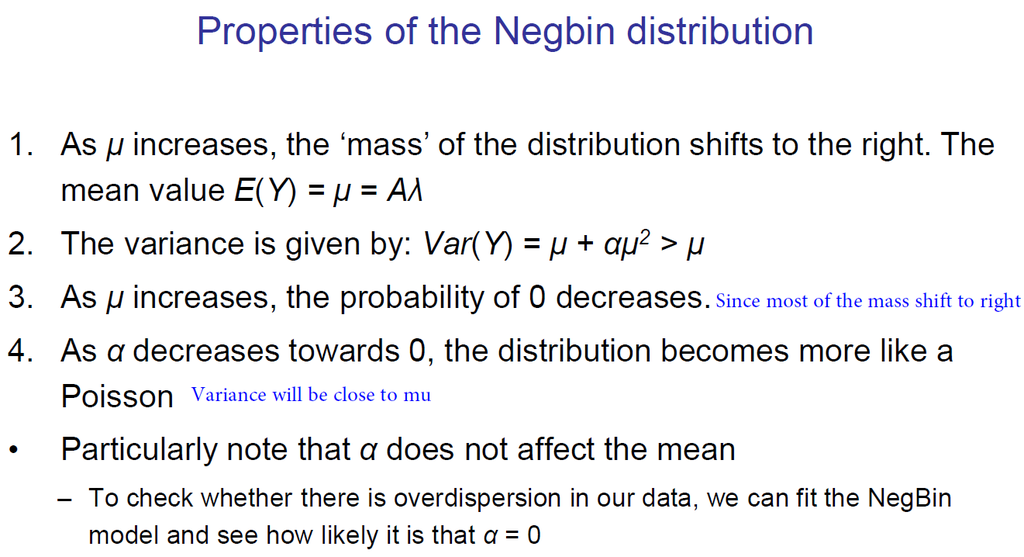

supplementary info